# Project Draft

### Members

- Hyun Ko
- **Kyle Yeo**
- Riley Larget
- Winsten Coellins

## Introduction

### Questions of Interest:

These are the questions of interest that we will analyze.

1. Is the type of college related to salary?
2. Is the type of region related to salary?
3. Which undergraduate major has the highest starting median salary?
4. Which undergraduate major has the highest mid career salary?
5. Which type of school has the highest starting median salary?
6. Which type of school has the highest mid career median salary?
7. Which region of schools has the highest starting median salary?
8. Which region of school has the highest mid career median salary?
9. Between the type of college and type of region, which one is more important to salary?
10. How does the initial salary relate to the increase in salary over time?

## Background

### About the raw data

There are three datasets, degrees-that-pay-back.csv, salaries-by-college-type.csv, and salaries-by-region.csv. we got this data from Kaggle, which is the official website that offers tons of different datasets to public. Each dataset was gathered from reports made to PayScale Inc. The first data called degrees-that-pay-back.csv consists of undergraduate majors with starting median salary and mid career median salary by stages from 10th percentile to 90th percentile. The second data called salaries-by-college-type.csv consists of the variables, school name, school type, starting median salary, and mid career salary also by stages from 10th percentile to 90th percentile. The third data also consists of similar structures with the first and second datasets with the variables, school name, region, starting median salary, and mid career median salary by stages from 10th percentile to 90th percentile. The topic of this analysis might be familiar to most of people, if not all, so that it might be not difficult to know the meaning of each variables. The variable undergraduate major indicates just the majors that are offered by college/university. The variable school name indicates the names of U.S. college or university and the region represents the location of college/universities like California. The variable school type means the type of school such as engineering school. The variable starting median salary indicates the median of the base salary and mid career median salary represents the level of salary after working for certain period of years. Lastly, the variable mid career x percentile means the level of a wage below a certain percent of workers. In the analysis, we combined the second and the third data for the research and analyze the first data separately.

### Datasets and variables used in the analysis

As we mentioned above, there are a number of variables in each datasets, but not all of them used in the analysis. we didn’t use the variables of mid career X percentile since we could well address the questions of interest without those variables.

### Shortcomings of the datasets

There are few shortcomings of our datasets. First of all, the data, degrees-that-pay-back, only has the names of the undergraduate majors, not with the schools so that we couldn’t combine it with the other two datasets. In addition, the variable of mid career median salary didn’t specify what “mid career” means so there’s no way to know about from which period of working years should be considered as mid career.

### The source of the data:

- https://www.kaggle.com/wsj/college-salaries

For the rest of the report we are going to tidy up three datasets appropriately and analyze our research questions with the numerical tibbles, graphs, linear models and t-tests.

## Analysis

### Cleaning up the data

As we mentioned in the background, we want to reformat and join the datasets

We apply two functions to the raw data. Firstly, we use a reformatting function since the original data has salaries as strings like “$79,000.00” and the function converted those into numbers like 79000. Also, we use a renaming function in order to make column names R-compliant. We then join the type dataset and region dataset by school name into a dataset of schools with both fields.

### Data distribution

[output not shown]

[output not shown]

For the numerical summaries, we made the first tibble of starting median salary and mid career median salary by the type of the school. The second tibble is similar but by the region of the school instead.

| undergraduate_major | mean_starting |
| --- | --- |
| Physician Assistant | 74300 |
| Chemical Engineering | 63200 |
| Computer Engineering | 61400 |
| Electrical Engineering | 60900 |
| Mechanical Engineering | 57900 |
| Aerospace Engineering | 57700 |
| Industrial Engineering | 57700 |
| Computer Science | 55900 |
| Nursing | 54200 |
| Civil Engineering | 53900 |

[output cut: 40 more lines]

| undergraduate_major | mean_mid_career |
| --- | --- |
| Chemical Engineering | 107000 |
| Computer Engineering | 105000 |
| Electrical Engineering | 103000 |
| Aerospace Engineering | 101000 |
| Economics | 98600 |
| Physics | 97300 |
| Computer Science | 95500 |
| Industrial Engineering | 94700 |
| Mechanical Engineering | 93600 |
| Math | 92400 |

[output cut: 40 more lines]

We made the above numerical table in order to analyze the relationship between the undergraduate majors and starting and mid career salary.

### Graphical summaries

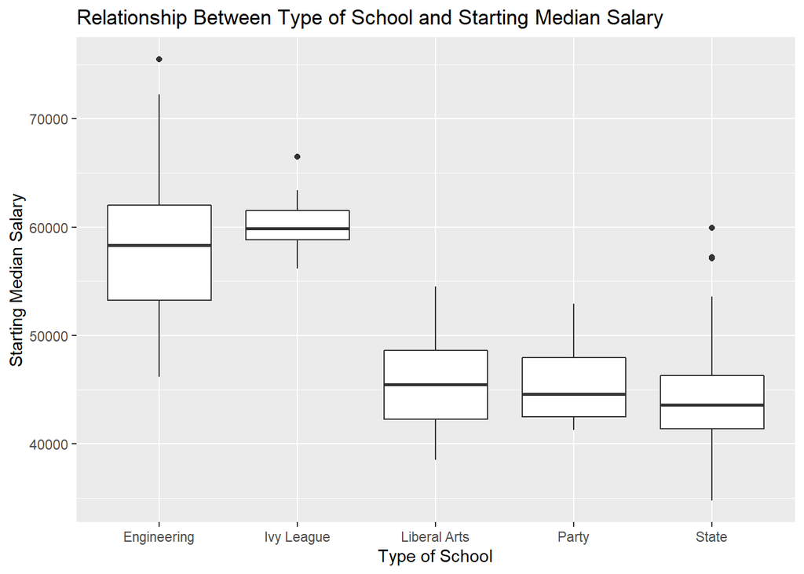

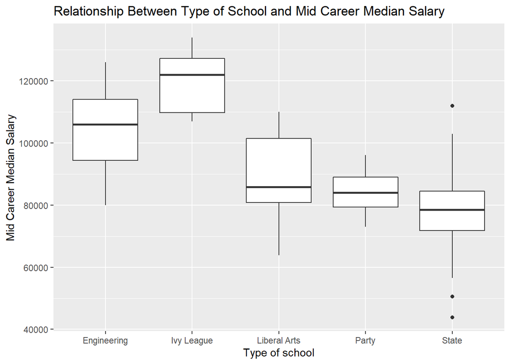

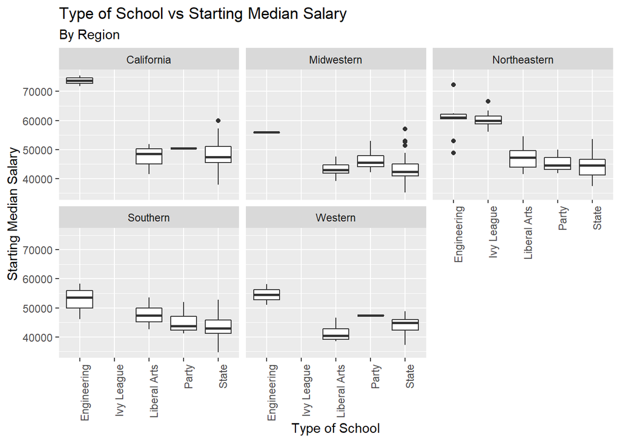

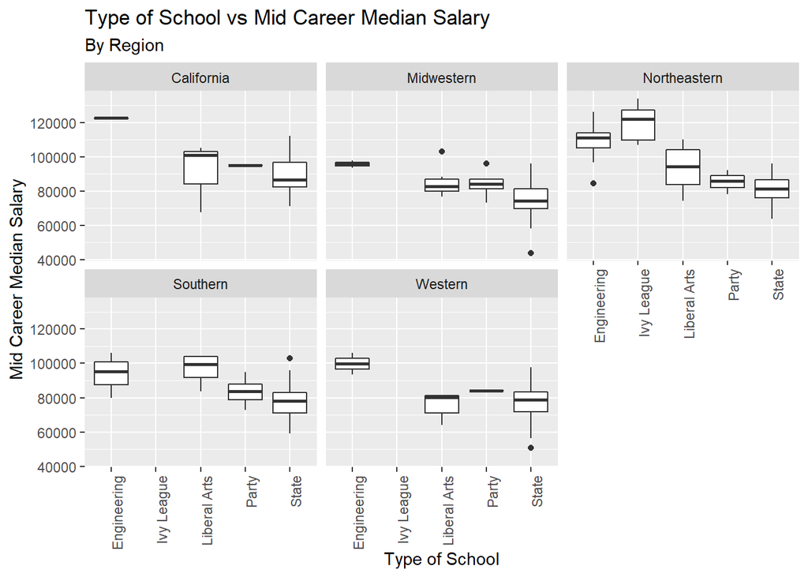

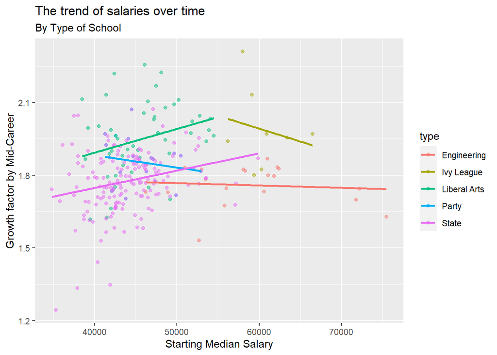

For this part, we made a boxplot and linear model with the type of school and salaries for figuring the relationship between the type of school and salary.

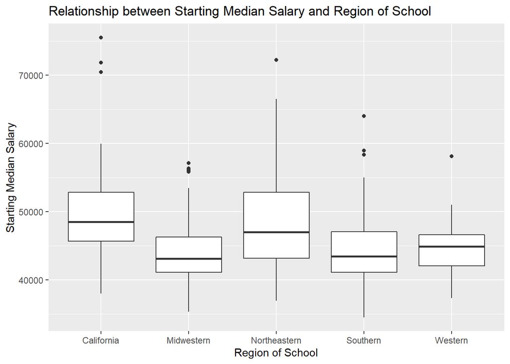

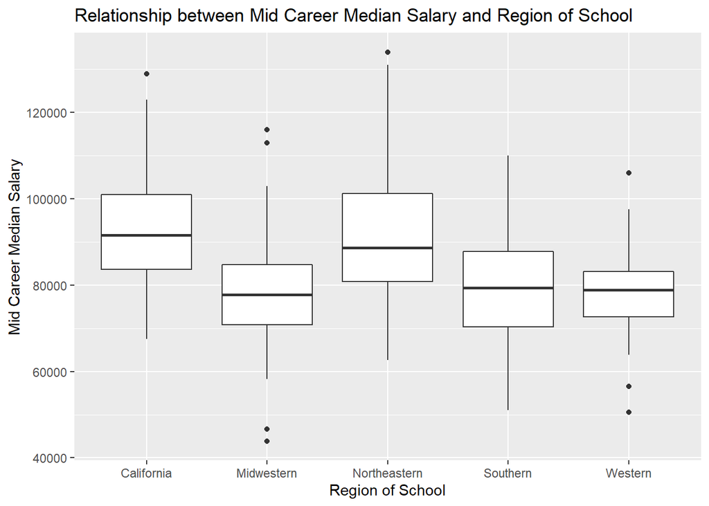

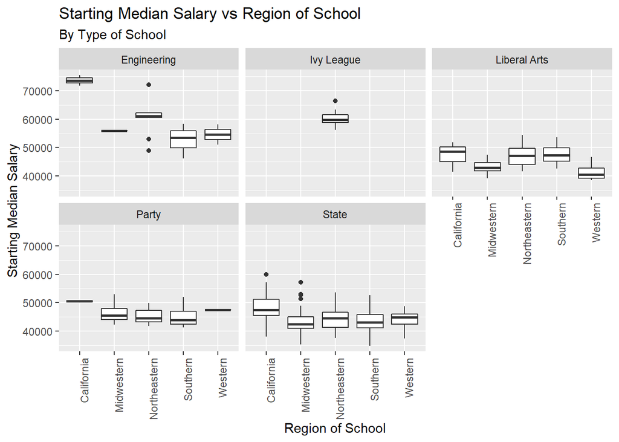

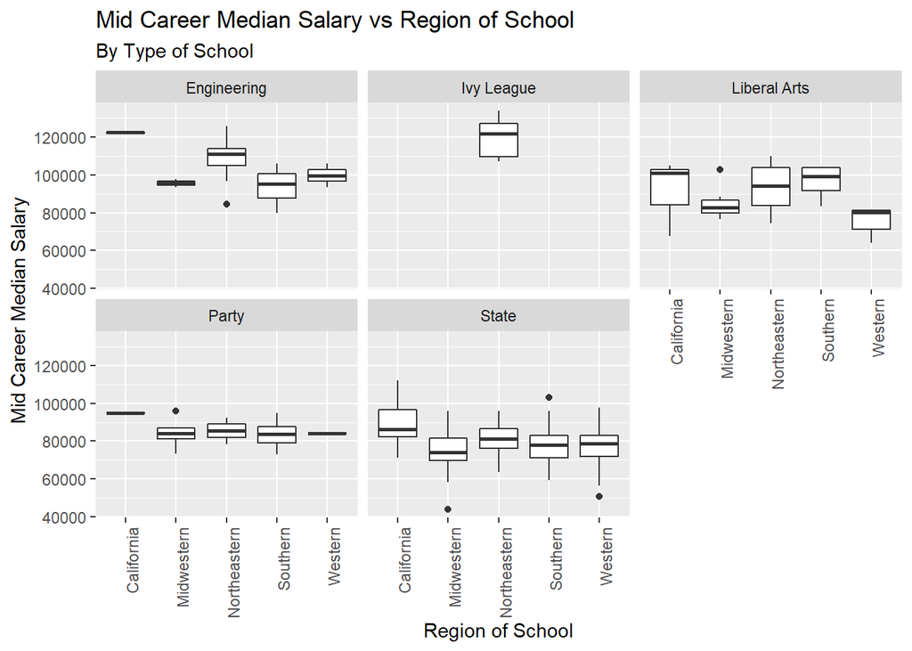

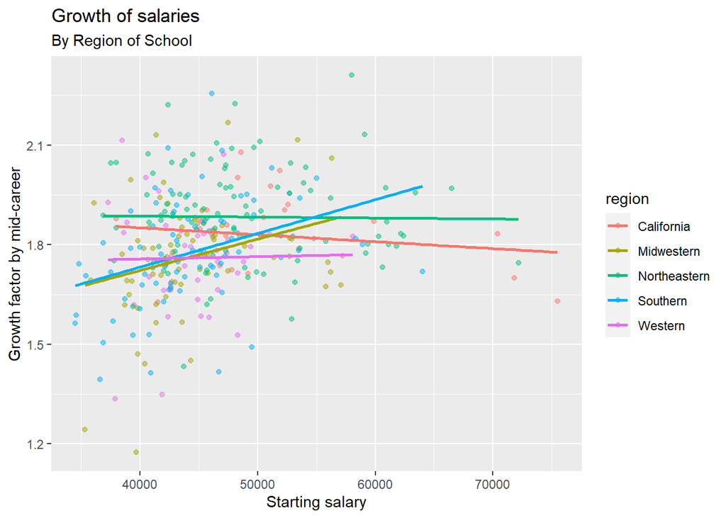

For this part, we visualized the relationship between the region of school and mid career median salary with boxplots and a linear model.

| type | salary_dependence | min_start | max_start | min_mid_career | max_mid_career |
| --- | --- | --- | --- | --- | --- |
| Liberal Arts | 9.796709e-06 | 38500 | 54500 | 63900 | 110000 |
| State | 7.131452e-06 | 34800 | 59900 | 43900 | 112000 |
| Engineering | -2.446067e-06 | 46200 | 75500 | 80000 | 126000 |
| Party | -5.046616e-06 | 41300 | 52900 | 73000 | 96100 |
| Ivy League | -1.061263e-05 | 56200 | 66500 | 107000 | 134000 |

| region | salary_dependence | min_start | max_start | min_mid_career | max_mid_career |
| --- | --- | --- | --- | --- | --- |
| Southern | 8.302094e-06 | 34800 | 58300 | 59200 | 106000 |
| Midwestern | 4.943978e-06 | 35300 | 57100 | 43900 | 103000 |
| Western | 2.612552e-06 | 37300 | 58100 | 50600 | 106000 |
| Northeastern | 4.382148e-07 | 37500 | 72200 | 63600 | 134000 |
| California | -2.576111e-06 | 38000 | 75500 | 67500 | 123000 |

We calculated the slope of each type and region of school with respect to starting salary and mid career salary growth rate. Positive slopes here show a widening distribution of salaries at mid career compared to at career start, while negative slopes show a tightening distribution of salaries. Relative magnitude of slopes show the strength of this effect.

## Hypothesis test with p values

Comparing Ivy League salaries to Engineering salaries:  
$H_0 : \mu_{Eng} = \mu_{Ivy}$  
$H_a : \mu_{Eng} \ne \mu_{Ivy}$  
For the starting median salary, p-value = 0.6307359 > 0.05. Therefore we cannot reject the null hypothesis that they have the same mean.  
For the mid-career median salary, p-value = 0.0061883 < 0.01. Therefore we can reject the null hypothesis that they have the same mean.

Comparing between region grouping for Party schools:  
$H_0 : \mu_{Party-CA,NE} = \mu_{Party-other}$  
$H_a : \mu_{Party-CA,NE} \ne \mu_{Party-other}$  
For the starting median salary, p-value = 0.6283073 > 0.05. Therefore we cannot reject the null hypothesis that they have the same mean.  
For the mid-career median salary, p-value = 0.3935479 > 0.05. Therefore we cannot reject the null hypothesis that they have the same mean.

## Discussion

### Discuss any potential short-comings of the analysis.

1. Some of the school presented in the data has more than one school type, therefore, it could affect the result that we have done
2. The degree data only has undergraduate major information, not with the school name so that it cannot be used with the type and region data.
3. There’s no information about graduate school by school or major.

### Potential future directions for additional work

#### Different methods to address the same questions

- We could do additional hypothesis testing for more groupings.

#### New questions

- Do the same majors from different university have effect on salary?

#### New data you might collect to refine your understanding

- Our current degree data only has the undergraduate majors with salary by stages. In order to address the new question, we need to collect the data that contains not only the majors, but also the school names with salary.